# BestModel

```python
! pip install catboost
# import gdown
# gdown.download('path_to_file_from_my_disk', 'file.csv', quiet=False)
```

```python
import numpy as np
import pandas as pd
import seaborn as sns
import matplotlib.pyplot as plt
from sklearn.model_selection import train_test_split, GridSearchCV
from sklearn.metrics import mean_absolute_error, r2_score
from sklearn.preprocessing import OneHotEncoder, MinMaxScaler, StandardScaler

from catboost import CatBoostRegressor
from sklearn.ensemble import RandomForestRegressor
from sklearn.linear_model import LinearRegression, Ridge, Lasso, ElasticNet

import os
import psutil

# df = pd.read_csv("file.csv")

path_to_file = './sample_data/price_laptop.csv'
df = pd.read_csv(path_to_file)
```

```python
# Функция для разделения строки на компонентыкомпоненты
def split_disk_info(disk_info):
    if 'TB' in disk_info:
        size = int(float(disk_info.split('TB')[0]) * 1024)
    else:
        size = int(disk_info.split('GB')[0])

    disk_type = 'SSD' if 'SSD' in disk_info else 'HDD'

    return pd.Series([size, disk_type])
```

Был проведен анализ признаков.  
Выяснилось, что такие категориальные признаки как *Resolution* и *Storage* можно перевести в более удобный формат.

```python
df[['width', 'height']] = df['Resolution'].str.split('x', expand=True).astype(int)
df[['SizeGB', 'disk type']] = df['Storage'].apply(split_disk_info) # Это улучшело качество на 1%
df = df.drop(columns=['Unnamed: 0.1', 'Unnamed: 0', 'Resolution', 'Storage'])
```

## Небольшой анализ признаков

```python
df.describe()
```

|  | RAM (GB) | Screen Size (inch) | Battery Life (hours) | Weight (kg) | Y | RAM latency | % defective devices (from 1000 pc) | QDR benchamrk | width | height | SizeGB |
| --- | --- | --- | --- | --- | --- | --- | --- | --- | --- | --- | --- |
| count | 11768.000000 | 11768.000000 | 11768.000000 | 11768.000000 | 11768.000000 | 11768.000000 | 11768.000000 | 11768.000000 | 11768.000000 | 11768.000000 | 11768.000000 |
| mean | 24.852821 | 15.212305 | 8.027855 | 2.341117 | 2183.571608 | 7.534925 | 10.006060 | 1238.943151 | 2426.974167 | 1365.079538 | 977.577158 |
| std | 21.762567 | 1.436997 | 2.305400 | 0.667921 | 1316.886132 | 0.551201 | 3.010088 | 431.853217 | 924.137138 | 519.934429 | 618.992798 |
| min | 4.000000 | 13.300000 | 4.000000 | 1.200000 | 279.570000 | 5.600000 | -1.050000 | -358.000000 | 1366.000000 | 768.000000 | 256.000000 |
| 25% | 8.000000 | 14.000000 | 6.000000 | 1.760000 | 1272.045000 | 7.100000 | 7.980000 | 950.000000 | 1920.000000 | 1080.000000 | 512.000000 |
| 50% | 16.000000 | 15.600000 | 8.000000 | 2.340000 | 1840.865000 | 7.500000 | 10.010000 | 1233.500000 | 2560.000000 | 1440.000000 | 1024.000000 |
| 75% | 32.000000 | 16.000000 | 10.000000 | 2.910000 | 2698.370000 | 7.900000 | 12.010000 | 1531.250000 | 3840.000000 | 2160.000000 | 1024.000000 |
| max | 64.000000 | 17.300000 | 12.000000 | 3.500000 | 10807.880000 | 9.300000 | 22.400000 | 2944.000000 | 3840.000000 | 2160.000000 | 2048.000000 |

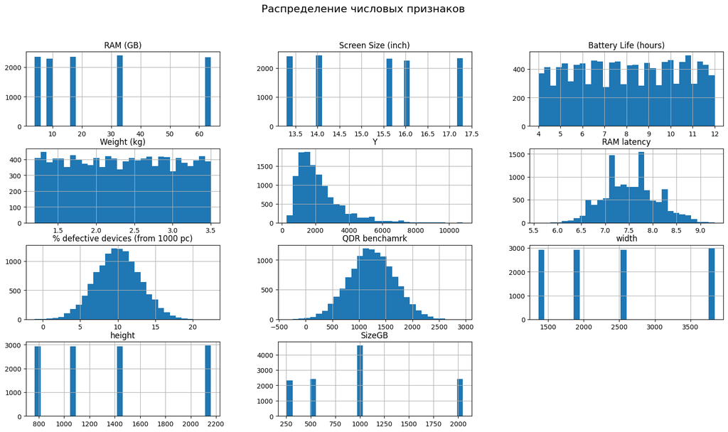

```python
df.hist(figsize=(19, 10), bins=30)
plt.suptitle("Распределение числовых признаков", fontsize=16)
plt.show()
```

Распределение числовых признаков хорошее и как следствие в предобработке данных нет необходимости.

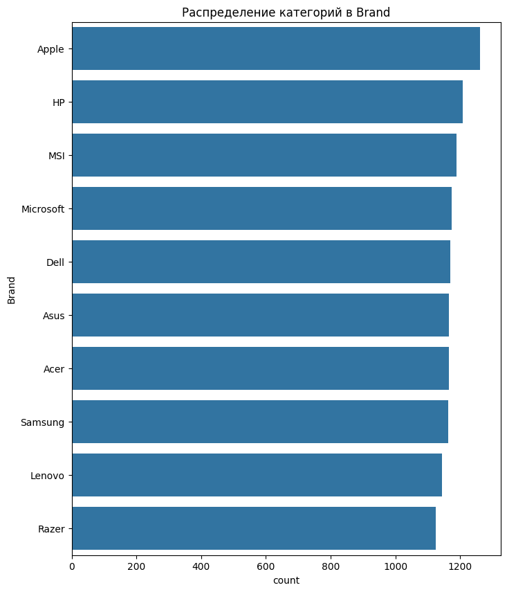

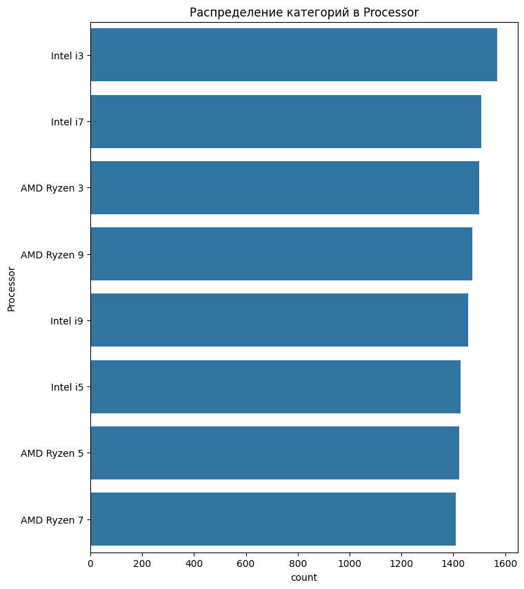

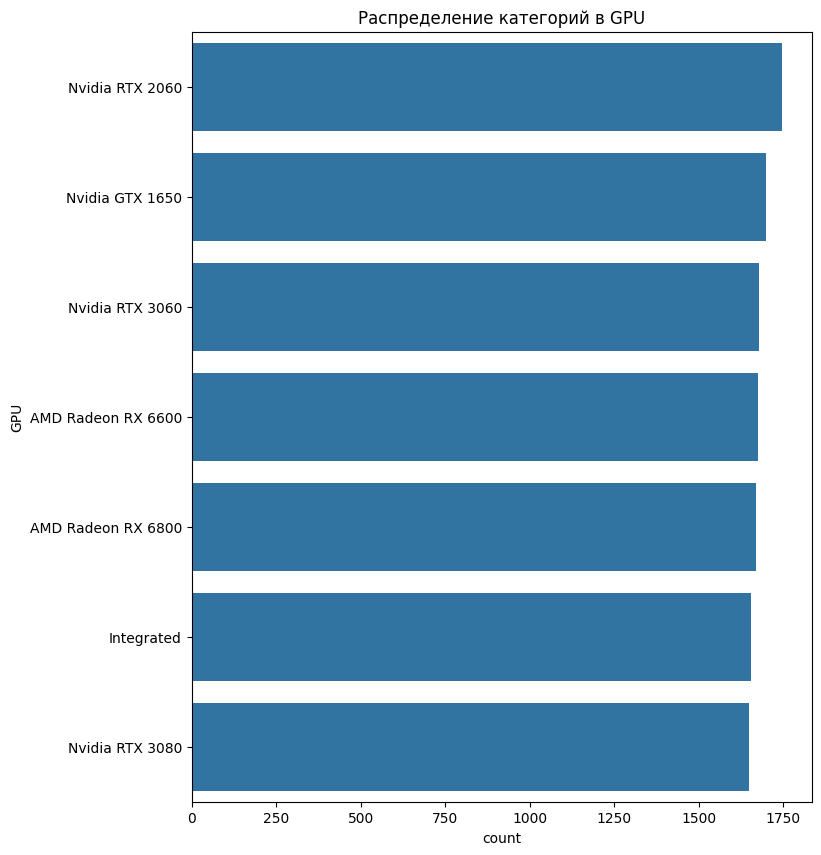

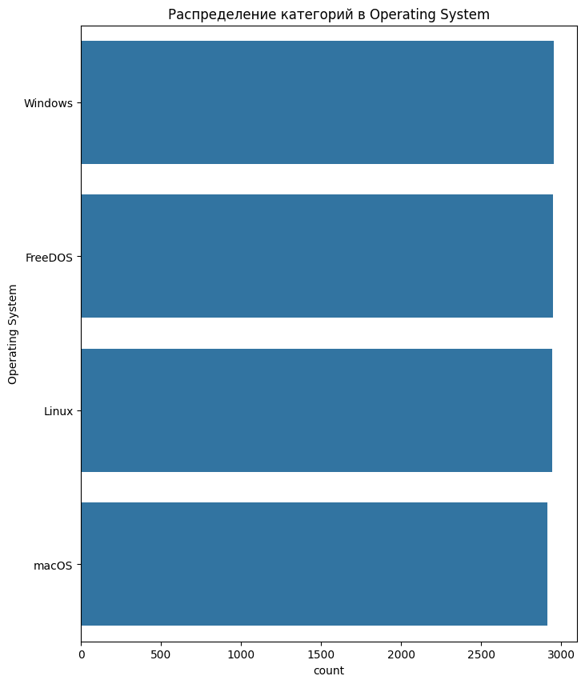

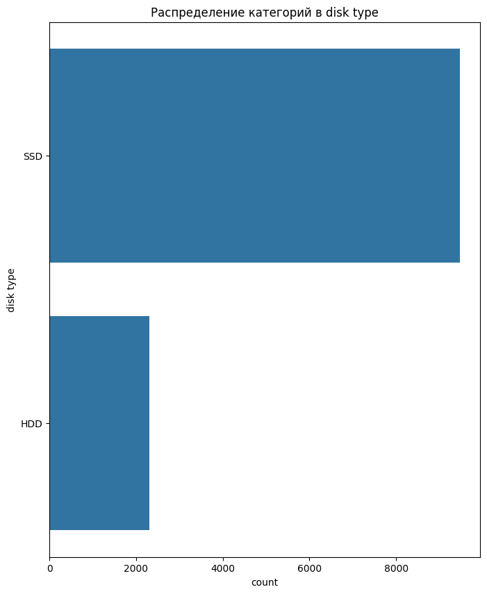

```python
for col in df.select_dtypes(include=["object", "category"]):
    plt.figure(figsize=(8, 10))
    sns.countplot(y=df[col], order=df[col].value_counts().index)
    plt.title(f"Распределение категорий в {col}")
    plt.show()
```

По построению моделей был сделан вывод, какие признаки больше всего влияют на целевую переменную

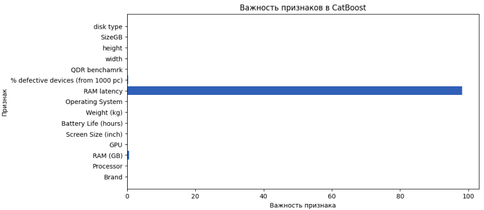

Я предполагаю, что целевой переменной(Y) является **стоимость ноутбука**. Так как прослживается явный рост цены к комплектующим.

Мною была обнаружена явная утечка данных, а именно один из признаков(RAM latency) равен натуральному логорифму целевой переменной(ln(Y)), тем более такой признак как RAM_latency не в состоянии так значительно влиять на цену ноутбкуа.  
Таким образом данный признак необходимо исключить, так как иначе модель получится слишком оптимистичной и нереалистичной для использования.

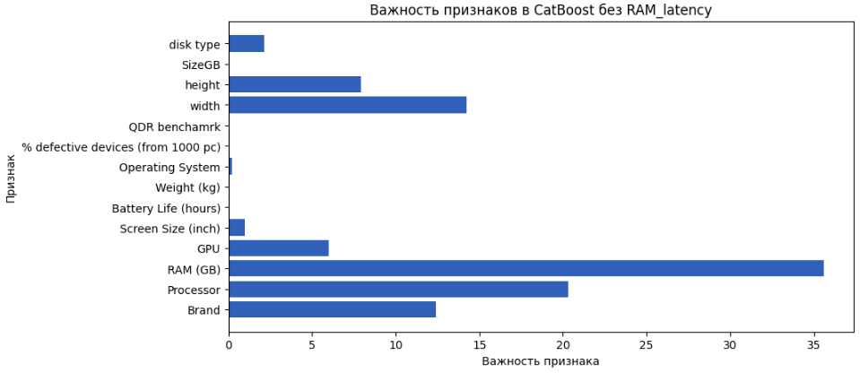

```python
df = df.drop(columns=['RAM latency', '% defective devices (from 1000 pc)', \
                      'Weight (kg)', 'QDR benchamrk', 'Battery Life (hours)', 'SizeGB'])
df = df.drop(columns='Operating System') ## Тоже улучшило качество моделей на несколько процентов
data_object = df.select_dtypes('object').columns
object_features = list(data_object)

data_numeric = df.select_dtypes(include=['int64', 'float64']).columns
data_numeric = data_numeric[data_numeric != 'Y']
numeric_features = list(data_numeric)

print(object_features)
print(numeric_features)
```

```
['Brand', 'Processor', 'GPU', 'disk type']
['RAM (GB)', 'Screen Size (inch)', 'width', 'height']
```

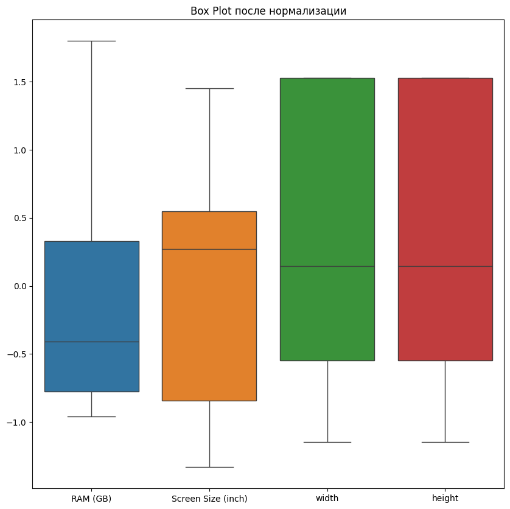

```python
scaler = StandardScaler()

X_normalized = scaler.fit_transform(df[data_numeric])
X_normalized = pd.DataFrame(X_normalized, columns=data_numeric)
plt.figure(figsize=(10, 10))
sns.boxplot(data=X_normalized)
plt.title('Box Plot после нормализации')
plt.show()
```

=> Шумовых данных нет

```python
X = df.drop('Y', axis=1)
Y = df['Y']

X_train, X_test, y_train, y_test = train_test_split(X, Y, test_size=0.2, random_state=42)
```

# Модель

Для начала, так как много категориальных признаков я решил попробовать модель CatBoostRegressor, так как это сильная модель, спасобная работать с категариальными признакми без их дополнительной обработки. Так же эта модель не переобучается.

```python
test_catboost_model = CatBoostRegressor(verbose=0)

param_grid = {
    'iterations': [100, 200, 300],
    'learning_rate': [0.1, 0.2, 0.3],
    'depth': [6, 8, 10],
}

grid_search = GridSearchCV(test_catboost_model, param_grid, cv=3, scoring='neg_mean_absolute_error', n_jobs=-1, verbose=2)

grid_search.fit(X_train, y_train, cat_features=object_features)

# best_model = grid_search.best_estimator_
# y_pred = best_model.predict(X_test)

print("Лучшие параметры: ", grid_search.best_params_)
print("Лучшая MAE на кросс-валидации: ", -grid_search.best_score_)
```

```
Fitting 3 folds for each of 27 candidates, totalling 81 fits
Лучшие параметры:  {'depth': 6, 'iterations': 300, 'learning_rate': 0.2}
Лучшая MAE на кросс-валидации:  81.89201001817865
```

```python
%%time

cpu_before = psutil.cpu_percent(interval=1)

CatBoost_model = CatBoostRegressor(**grid_search.best_params_, verbose=0)

CatBoost_model.fit(X_train, y_train, cat_features=object_features)

cpu_after = psutil.cpu_percent(interval=1)

y_pred = CatBoost_model.predict(X_test)

mae = mean_absolute_error(y_test, y_pred)
r2 = r2_score(y_test, y_pred)

print(f"MAE: {mae}")
print(f"R2: {r2}")
print(f"CPU used: {cpu_after}%")
```

```
MAE: 79.09347741742509
R2: 0.9949734395363429
CPU used: 2.0%
CPU times: user 2.81 s, sys: 181 ms, total: 2.99 s
Wall time: 3.6 s
```

# Теперь OneHotEncoding + другие модели

```python
enc = OneHotEncoder(sparse_output=False, handle_unknown='ignore')
enc.fit(X_train[object_features])

# Преобразование категориальных признаков
X_train_ohe = enc.transform(X_train[object_features])
X_test_ohe = enc.transform(X_test[object_features])

X_train_number = np.array(X_train.select_dtypes('number'))
X_test_number = np.array(X_test.select_dtypes('number'))

# Масштабирование числовых признаков
scaler = StandardScaler()
scaler.fit(X_train_number)

X_train_number_scaled = scaler.transform(X_train_number)
X_test_number_scaled = scaler.transform(X_test_number)

# Объединение числовых и категориальных признаков
X_train_new = np.hstack((X_train_number_scaled, X_train_ohe))
X_test_new = np.hstack((X_test_number_scaled, X_test_ohe))
```

Предвaрительно был так же проведен GridSearch для поиска наилучших гиперпараметров.  
'n_estimators': [100, 200, 300], # Количество деревьев  
'max_depth': [None, 5, 10], # Глубина деревьев  
'min_samples_split': [2, 5, 10], # Минимальное количество образцов для разделения  
'min_samples_leaf': [1, 2, 4] # Минимальное количество образцов в листе  
Но лучшая модель оказалась та, у которой наибольшее количество n_estimators(деревьев). Поэтому подберем такую, что время и качество будут в совокупности давать максимальную эффективность

```python
%%time

cpu_before = psutil.cpu_percent(interval=1)

forest_model = RandomForestRegressor(n_estimators=400, n_jobs=-1, random_state=42)
forest_model.fit(X_train_new, y_train)

cpu_after = psutil.cpu_percent(interval=1)

y_pred = forest_model.predict(X_test_new)

mae = mean_absolute_error(y_test, y_pred)
r2 = r2_score(y_test, y_pred)

print(f"MAE: {mae:.6f}")
print(f"R2: {r2:.6f}")
print(f"CPU used: {cpu_after}%")
```

```
MAE: 112.555609
R2: 0.984921
CPU used: 1.5%
CPU times: user 23.3 s, sys: 397 ms, total: 23.7 s
Wall time: 15.5 s
```

## Попробуем какую то простую модель регрессии

```python
%%time

Linear_model = LinearRegression()

Linear_model.fit(X_train_new, y_train)

y_pred = Linear_model.predict(X_test_new)

mae = mean_absolute_error(y_test, y_pred)
r2 = r2_score(y_test, y_pred)

print(f"MAE: {mae}")
print(f"R2: {r2}")
```

```
MAE: 320.7082554594241
R2: 0.8795705430446144
CPU times: user 27.6 ms, sys: 7.96 ms, total: 35.6 ms
Wall time: 22.5 ms
```

```python
%%time

lasso_model = Lasso(alpha=0.1)
lasso_model.fit(X_train_new, y_train)
y_pred = lasso_model.predict(X_test_new)

mae = mean_absolute_error(y_test, y_pred)
r2 = r2_score(y_test, y_pred)

print(f"MAE: {mae}")
print(f"R2: {r2}")
```

```
MAE: 320.1441186336293
R2: 0.8795942465898076
CPU times: user 165 ms, sys: 34.8 ms, total: 199 ms
Wall time: 137 ms
```

```python
%%time

ridge_model = Ridge(alpha=1.0)

ridge_model.fit(X_train_new, y_train)

y_pred = ridge_model.predict(X_test_new)

mae = mean_absolute_error(y_test, y_pred)
r2 = r2_score(y_test, y_pred)

print(f"MAE: {mae}")
print(f"R2: {r2}")
```

```
MAE: 320.21064925302824
R2: 0.879582275372241
CPU times: user 14.2 ms, sys: 7.51 ms, total: 21.7 ms
Wall time: 13.6 ms
```

```python
Elastic_model = ElasticNet(max_iter=10000)

param_grid = {
    'alpha': [0.01, 0.1, 1, 10, 100],  # Сила регуляризации
    'l1_ratio': [0, 0.25, 0.5, 0.75, 1]  # Соотношение L1/L2 (0 = Ridge, 1 = Lasso)
}

grid_search = GridSearchCV(estimator=Elastic_model, param_grid=param_grid,
                           scoring='neg_mean_absolute_error', cv=5)

grid_search.fit(X_train_new, y_train)

print(f"Лучшие гиперпараметры: {grid_search.best_params_}")
```

[output not shown]

[output cut: 17 more lines]

```
Лучшие гиперпараметры: {'alpha': 0.1, 'l1_ratio': 0.75}
```

```python
%%time


cpu_before = psutil.cpu_percent(interval=1)

elastic_model = ElasticNet(**grid_search.best_params_)

elastic_model.fit(X_train_new, y_train)

cpu_after = psutil.cpu_percent(interval=1)

y_pred = elastic_model.predict(X_test_new)

mae = mean_absolute_error(y_test, y_pred)
r2 = r2_score(y_test, y_pred)

print(f"MAE: {mae}")
print(f"R2: {r2}")
print(f"CPU used: {cpu_after}%")
```

```
MAE: 308.86811531584436
R2: 0.8696842738806352
CPU used: 2.0%
CPU times: user 53.1 ms, sys: 60.7 ms, total: 114 ms
Wall time: 2.04 s
```

## Полиноминальная регрессия

```python
%%time

from sklearn.preprocessing import PolynomialFeatures

degree = 3

# Преобразование признаков в полиномиальные
poly = PolynomialFeatures(degree)
X_train_poly = poly.fit_transform(X_train_new)
X_test_poly = poly.transform(X_test_new)

cpu_before = psutil.cpu_percent(interval=1)

model = LinearRegression()
model.fit(X_train_poly, y_train)

cpu_after = psutil.cpu_percent(interval=1)

y_pred = model.predict(X_test_poly)

mae = mean_absolute_error(y_test, y_pred)
r2 = r2_score(y_test, y_pred)

print(f"MAE: {mae}")
print(f"R2: {r2}")
print(f"CPU used: {cpu_after}%")
```

```
MAE: 83.41698970824282
R2: 0.9943114598597376
CPU used: 10.1%
CPU times: user 6min 28s, sys: 3.01 s, total: 6min 31s
Wall time: 3min 48s
```

[output not shown]

=> самой эффективной моделью является CatBoost